# Meta-analysis of genes [DRAFT]

### PFKP

**Statistics of PFKP meta-analisys**

```r
kable(sig.genes.df['PFKP',1:11])
```

|  | lower_bound | logFC | upper_bound | pvalue | QE | QEp | SE | tau2 | I2 | H2 | p.adjust.fdr |
| --- | --- | --- | --- | --- | --- | --- | --- | --- | --- | --- | --- |
| PFKP | -0.129 | -0.09 | -0.051 | 0 | 6.922 | 0.437 | 0.02 | 0 | 0 | 1 | 0.011 |

[Gene information](https://www.genecards.org/cgi-bin/carddisp.pl?gene=PFKP)

**Forest plot**

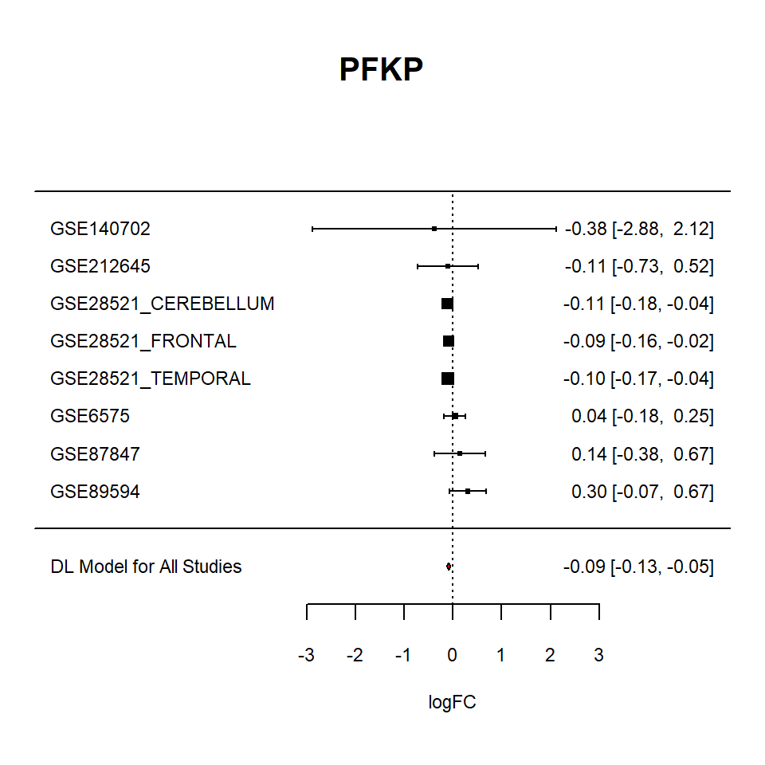

```r
knitr::include_graphics("plots/PFKP_FOREST.png")
```

**Funnel plot**

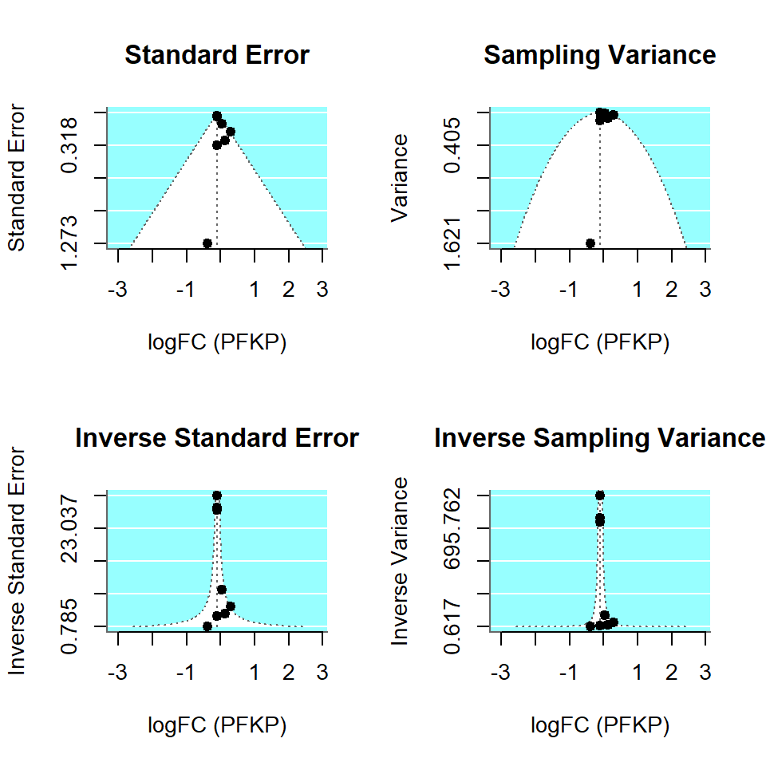

```r
knitr::include_graphics("plots/PFKP_FUNNEL.png")
```

**Incluence plot**

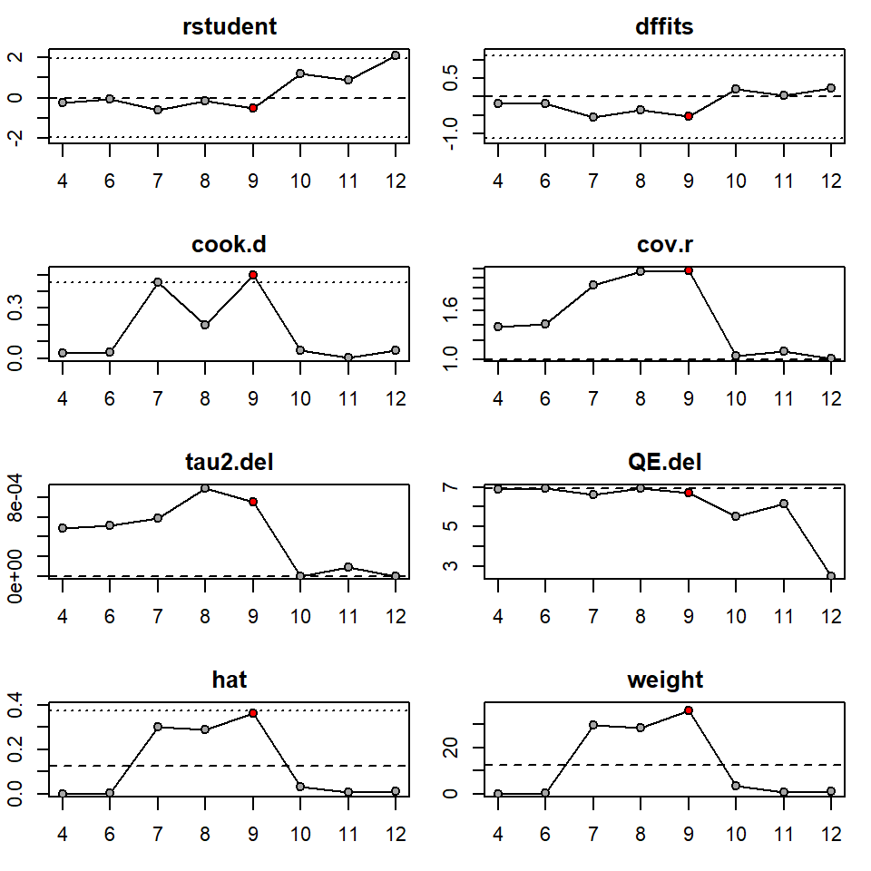

```r
knitr::include_graphics("plots/PFKP_INFLUENCE.png")
```

### TSPAN33

**Statistics of TSPAN33 meta-analisys**

```r
kable(sig.genes.df['TSPAN33',1:11])
```

|  | lower_bound | logFC | upper_bound | pvalue | QE | QEp | SE | tau2 | I2 | H2 | p.adjust.fdr |
| --- | --- | --- | --- | --- | --- | --- | --- | --- | --- | --- | --- |
| TSPAN33 | 0.049 | 0.086 | 0.122 | 0 | 6.303 | 0.789 | 0.019 | 0 | 0 | 1 | 0.011 |

[Gene information](https://www.genecards.org/cgi-bin/carddisp.pl?gene=TSPAN33)

**Forest plot**

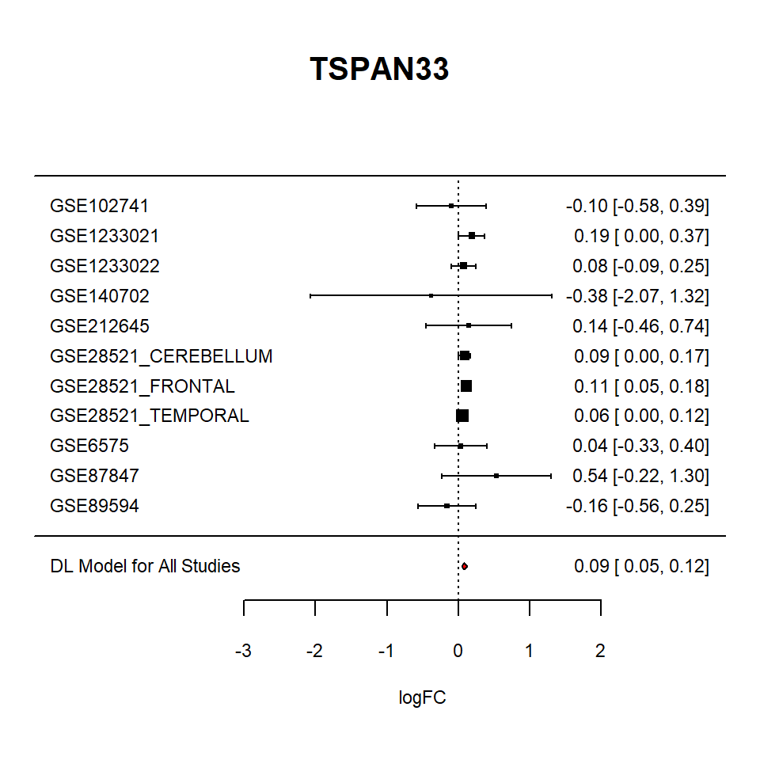

```r
knitr::include_graphics("plots/TSPAN33_FOREST.png")
```

**Funnel plot**

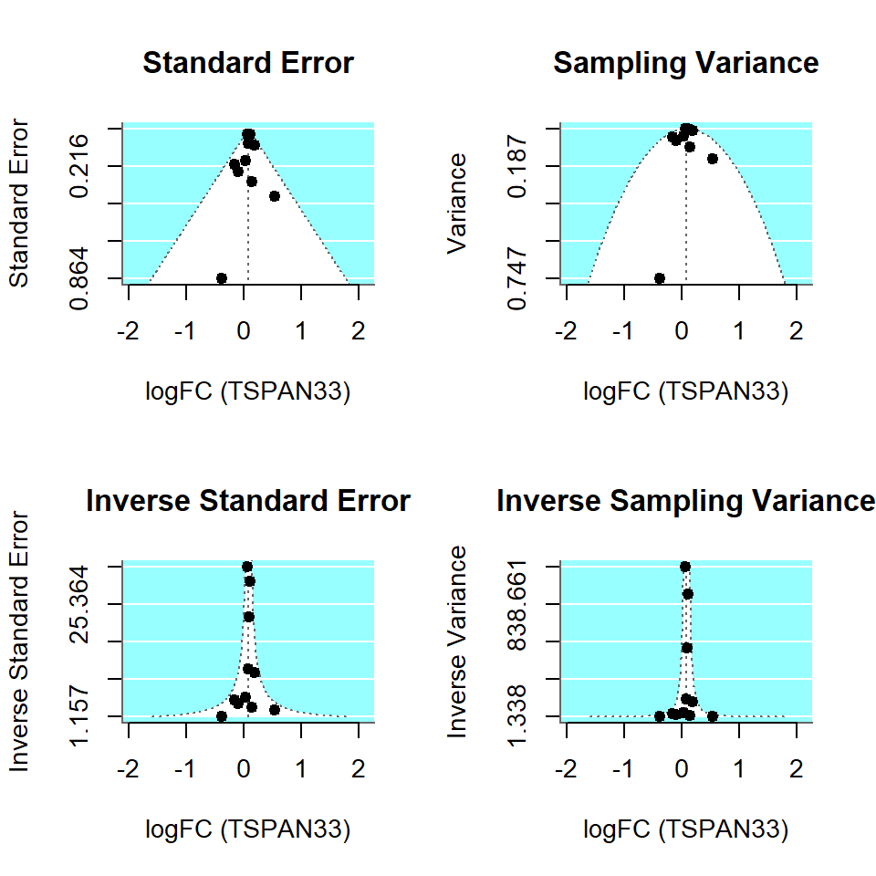

```r
knitr::include_graphics("plots/TSPAN33_FUNNEL.png")
```

**Incluence plot**

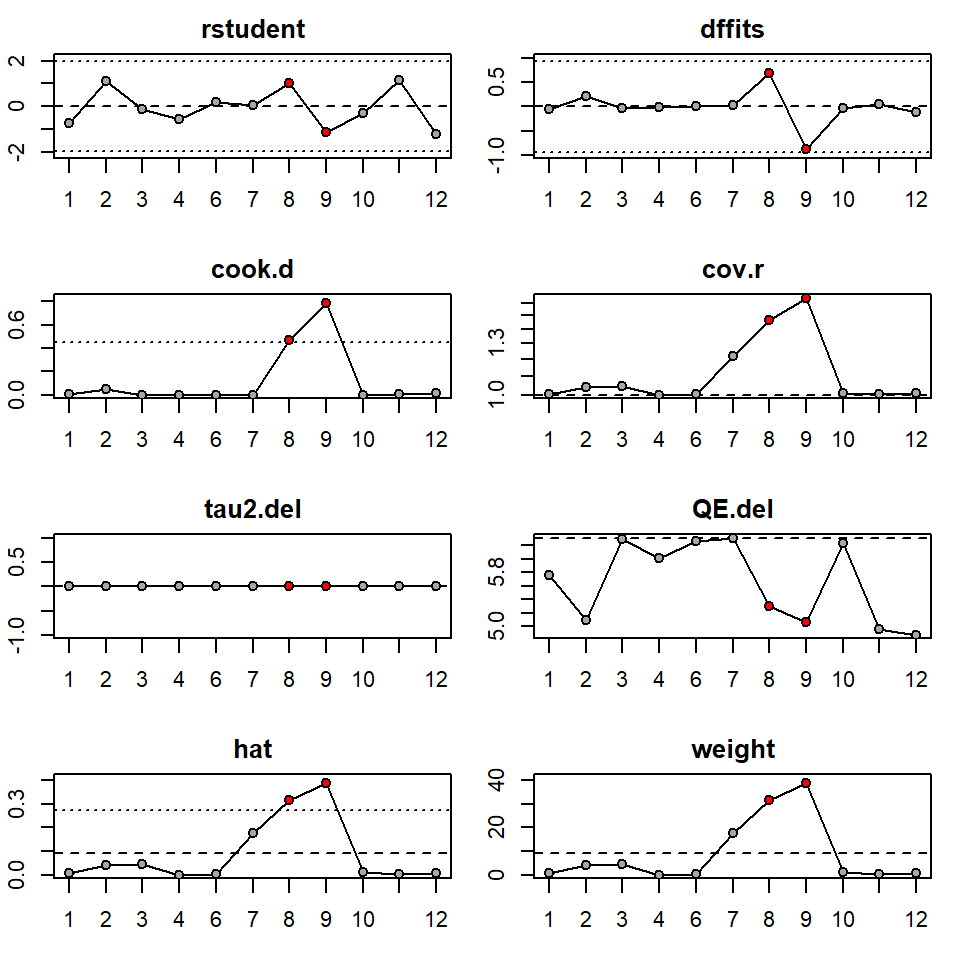

```r
knitr::include_graphics("plots/TSPAN33_INFLUENCE.png")
```

### ZFR

**Statistics of ZFR meta-analisys**

```r
kable(sig.genes.df['ZFR',1:11])
```

|  | lower_bound | logFC | upper_bound | pvalue | QE | QEp | SE | tau2 | I2 | H2 | p.adjust.fdr |
| --- | --- | --- | --- | --- | --- | --- | --- | --- | --- | --- | --- |
| ZFR | 0.029 | 0.051 | 0.073 | 0 | 4.322 | 0.932 | 0.011 | 0 | 0 | 1 | 0.012 |

[Gene information](https://www.genecards.org/cgi-bin/carddisp.pl?gene=ZFR)

**Forest plot**

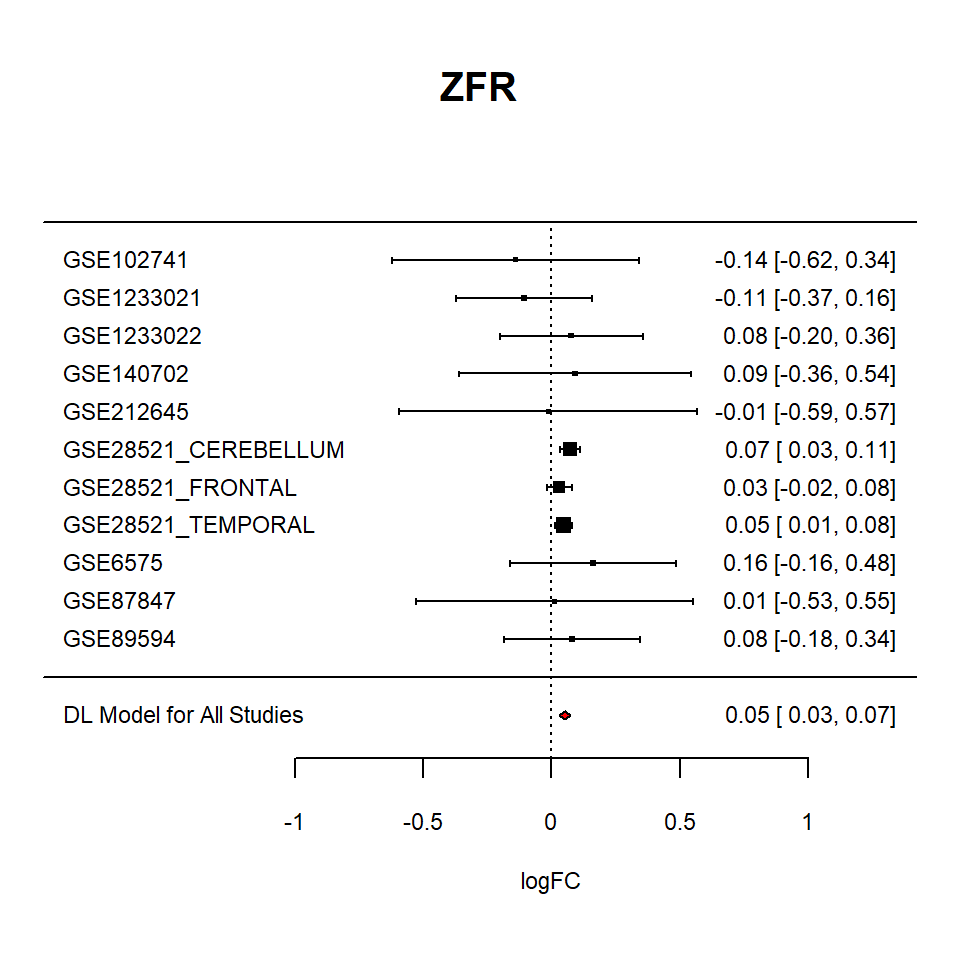

```r
knitr::include_graphics("plots/ZFR_FOREST.png")
```

**Funnel plot**

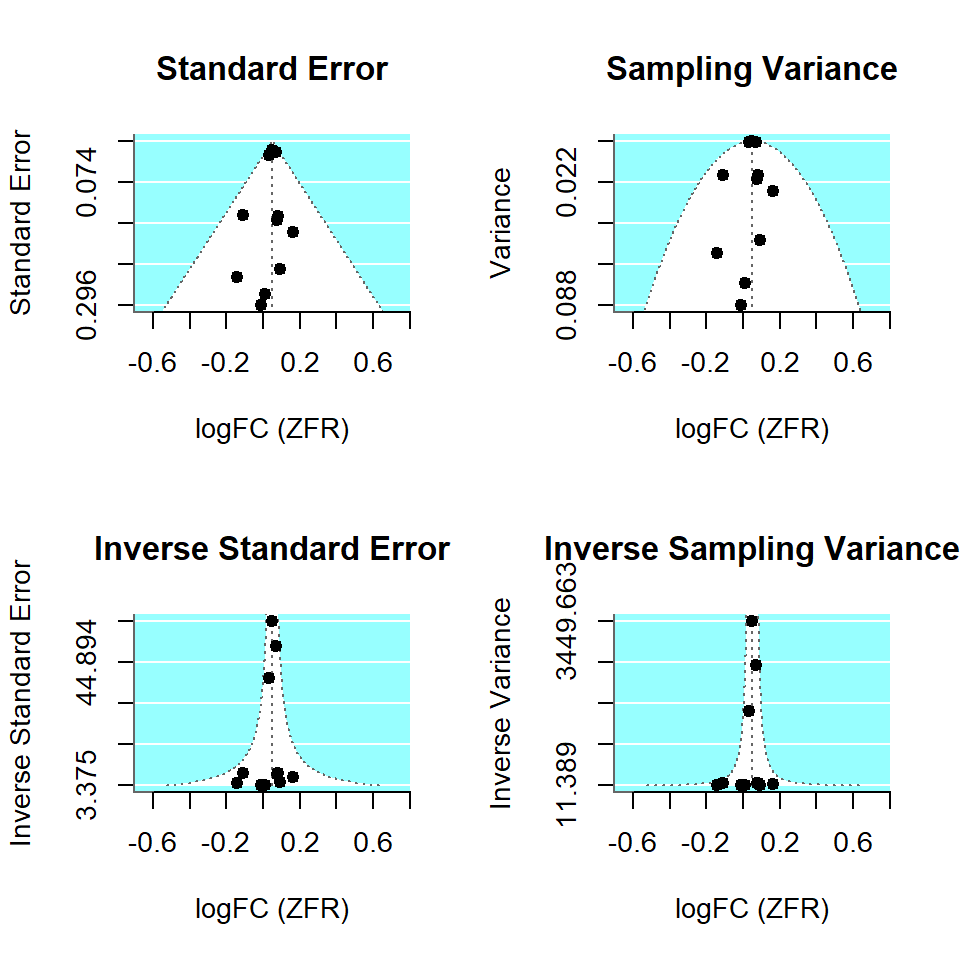

```r
knitr::include_graphics("plots/ZFR_FUNNEL.png")
```

**Incluence plot**

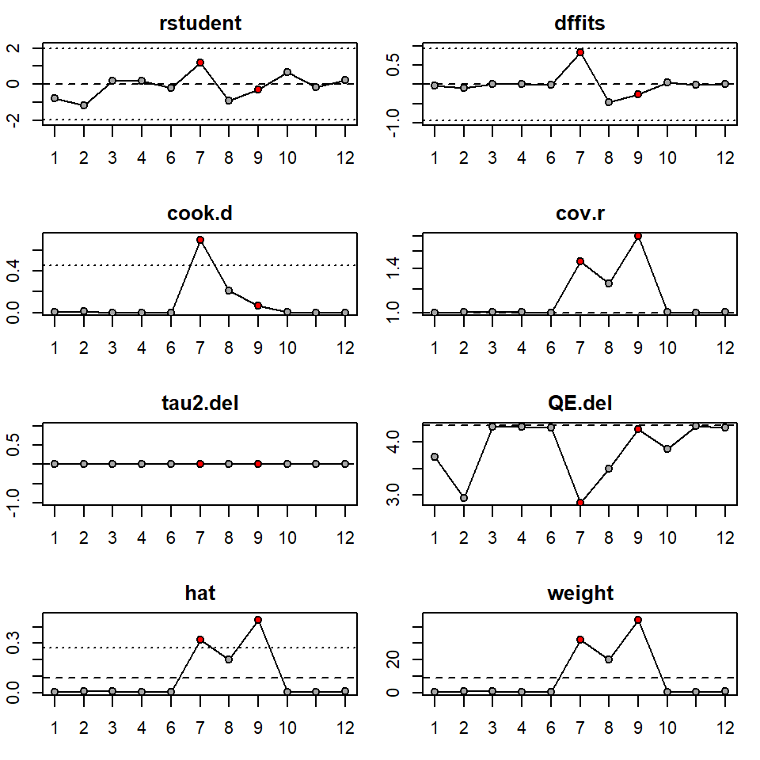

```r
knitr::include_graphics("plots/ZFR_INFLUENCE.png")
```

### DFFA

**Statistics of DFFA meta-analisys**

```r
kable(sig.genes.df['DFFA',1:11])
```

|  | lower_bound | logFC | upper_bound | pvalue | QE | QEp | SE | tau2 | I2 | H2 | p.adjust.fdr |
| --- | --- | --- | --- | --- | --- | --- | --- | --- | --- | --- | --- |
| DFFA | 0.062 | 0.11 | 0.158 | 0 | 7.198 | 0.515 | 0.025 | 0 | 0 | 1 | 0.013 |

[Gene information](https://www.genecards.org/cgi-bin/carddisp.pl?gene=DFFA)

**Forest plot**

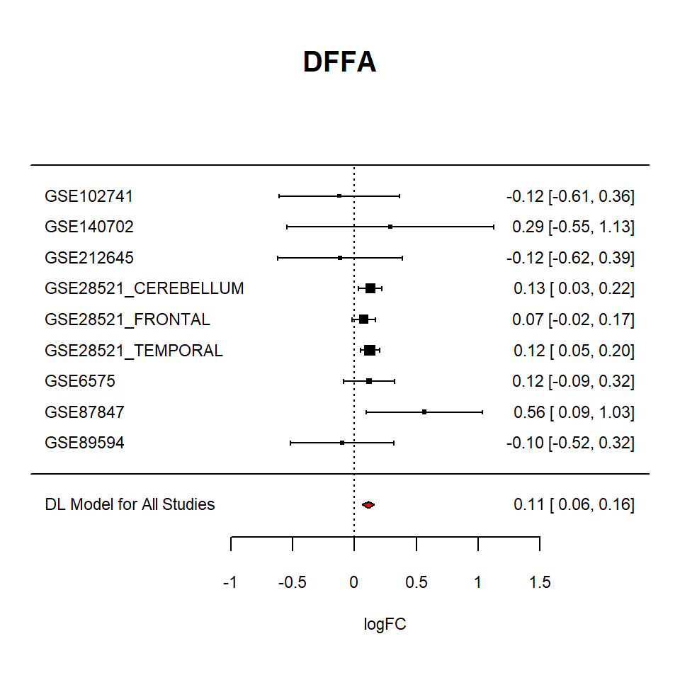

```r
knitr::include_graphics("plots/DFFA_FOREST.png")
```

**Funnel plot**

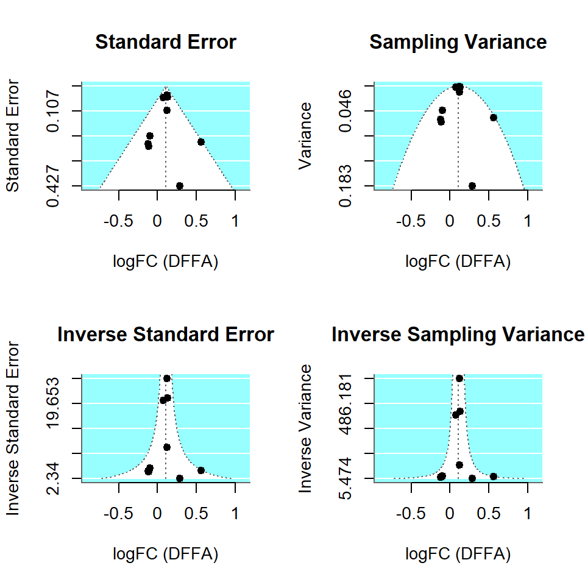

```r
knitr::include_graphics("plots/DFFA_FUNNEL.png")
```

**Incluence plot**

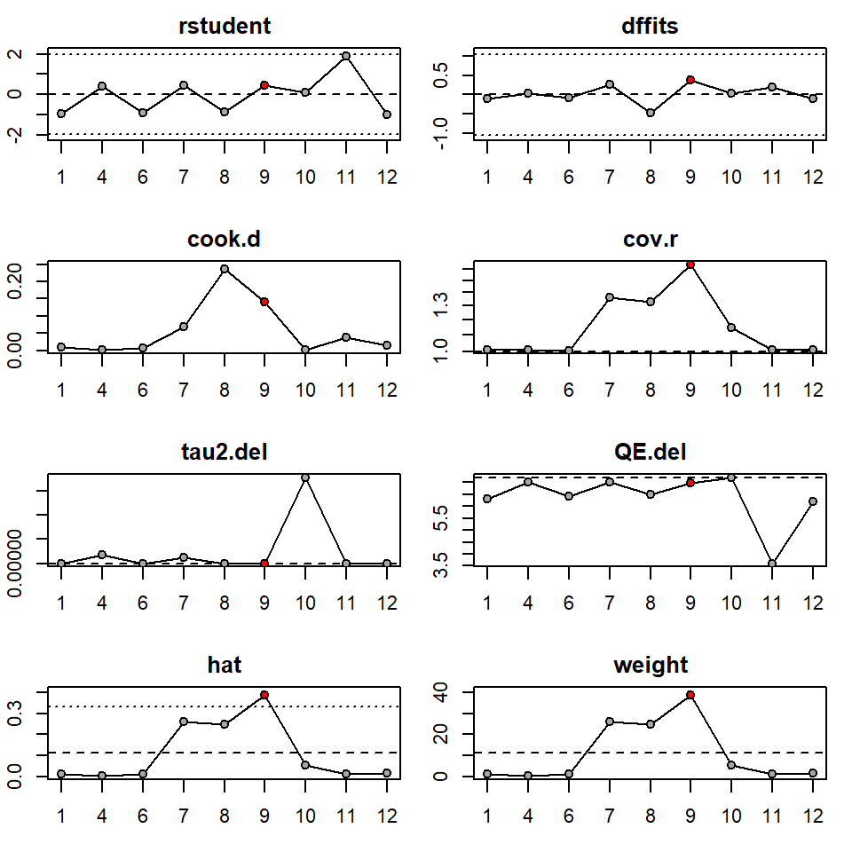

```r
knitr::include_graphics("plots/DFFA_INFLUENCE.png")
```

### TCEA3

**Statistics of TCEA3 meta-analisys**

```r
kable(sig.genes.df['TCEA3',1:11])
```

|  | lower_bound | logFC | upper_bound | pvalue | QE | QEp | SE | tau2 | I2 | H2 | p.adjust.fdr |
| --- | --- | --- | --- | --- | --- | --- | --- | --- | --- | --- | --- |
| TCEA3 | 0.075 | 0.136 | 0.196 | 0 | 4.879 | 0.77 | 0.031 | 0 | 0 | 1 | 0.018 |

[Gene information](https://www.genecards.org/cgi-bin/carddisp.pl?gene=TCEA3)

**Forest plot**

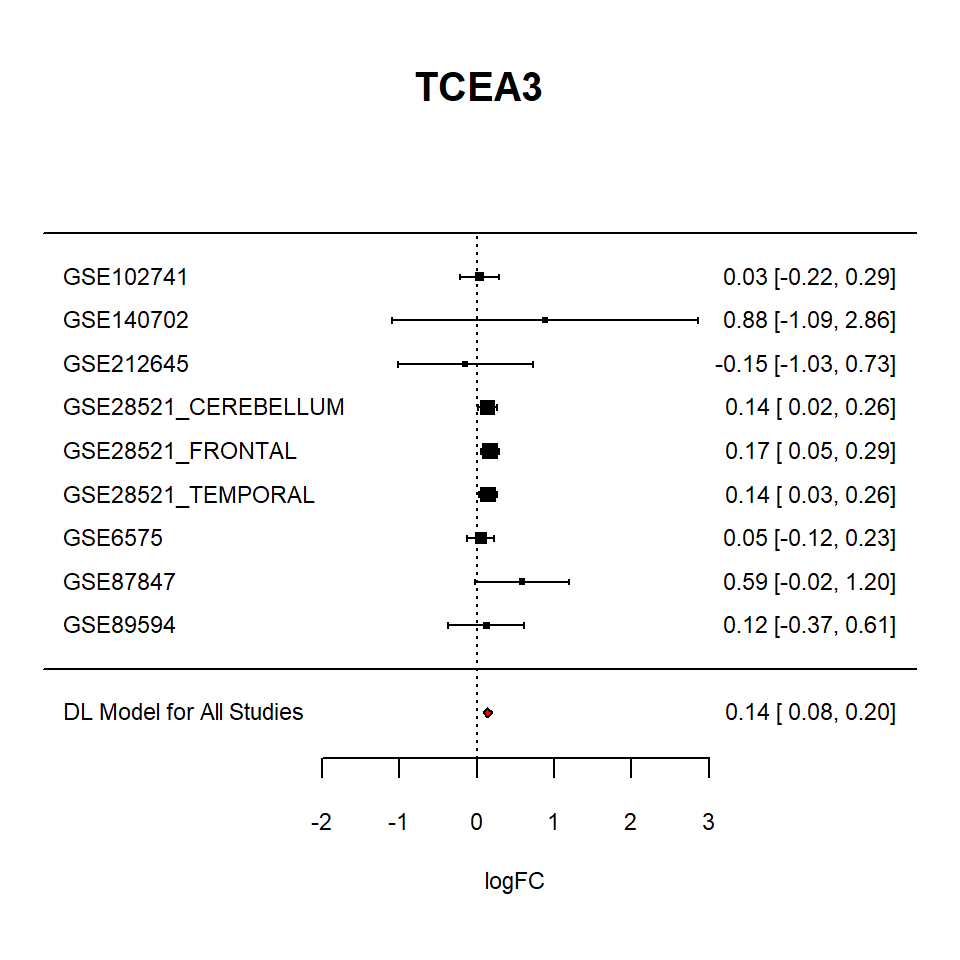

```r
knitr::include_graphics("plots/TCEA3_FOREST.png")
```

**Funnel plot**

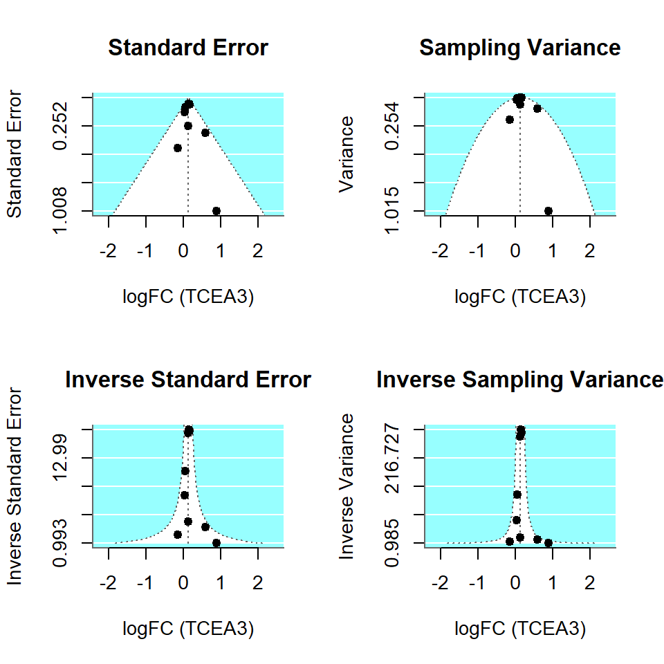

```r
knitr::include_graphics("plots/TCEA3_FUNNEL.png")
```

**Incluence plot**

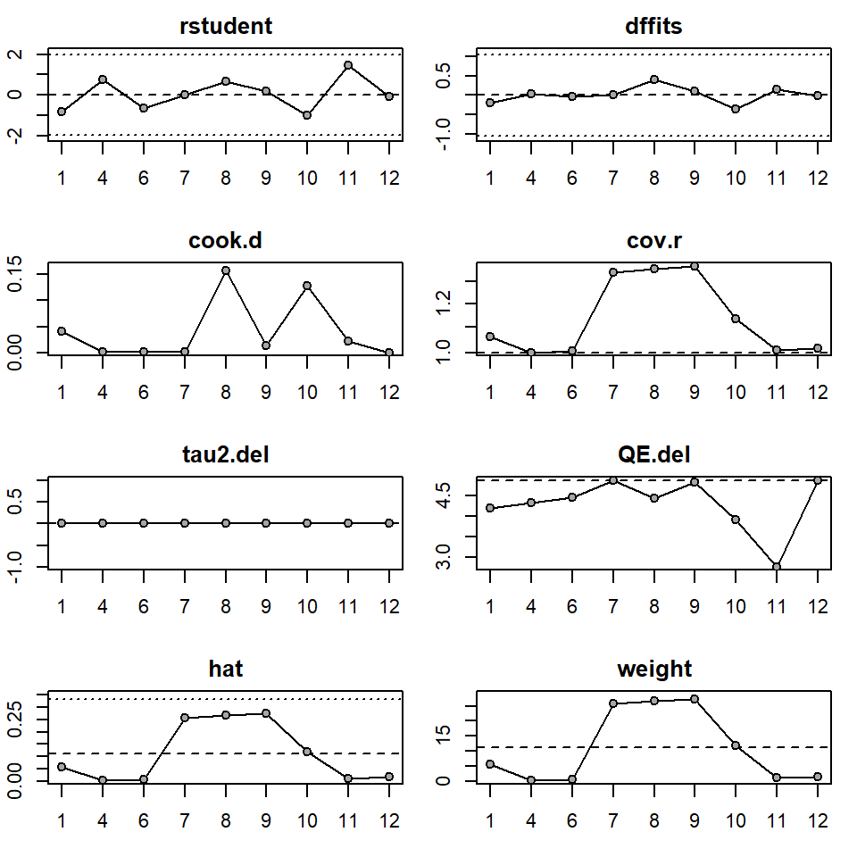

```r
knitr::include_graphics("plots/TCEA3_INFLUENCE.png")
```

### AMTN

**Statistics of AMTN meta-analisys**

```r
kable(sig.genes.df['AMTN',1:11])
```

|  | lower_bound | logFC | upper_bound | pvalue | QE | QEp | SE | tau2 | I2 | H2 | p.adjust.fdr |
| --- | --- | --- | --- | --- | --- | --- | --- | --- | --- | --- | --- |
| AMTN | -0.434 | -0.3 | -0.165 | 0 | 1.401 | 0.705 | 0.069 | 0 | 0 | 1 | 0.02 |

[Gene information](https://www.genecards.org/cgi-bin/carddisp.pl?gene=AMTN)

**Forest plot**

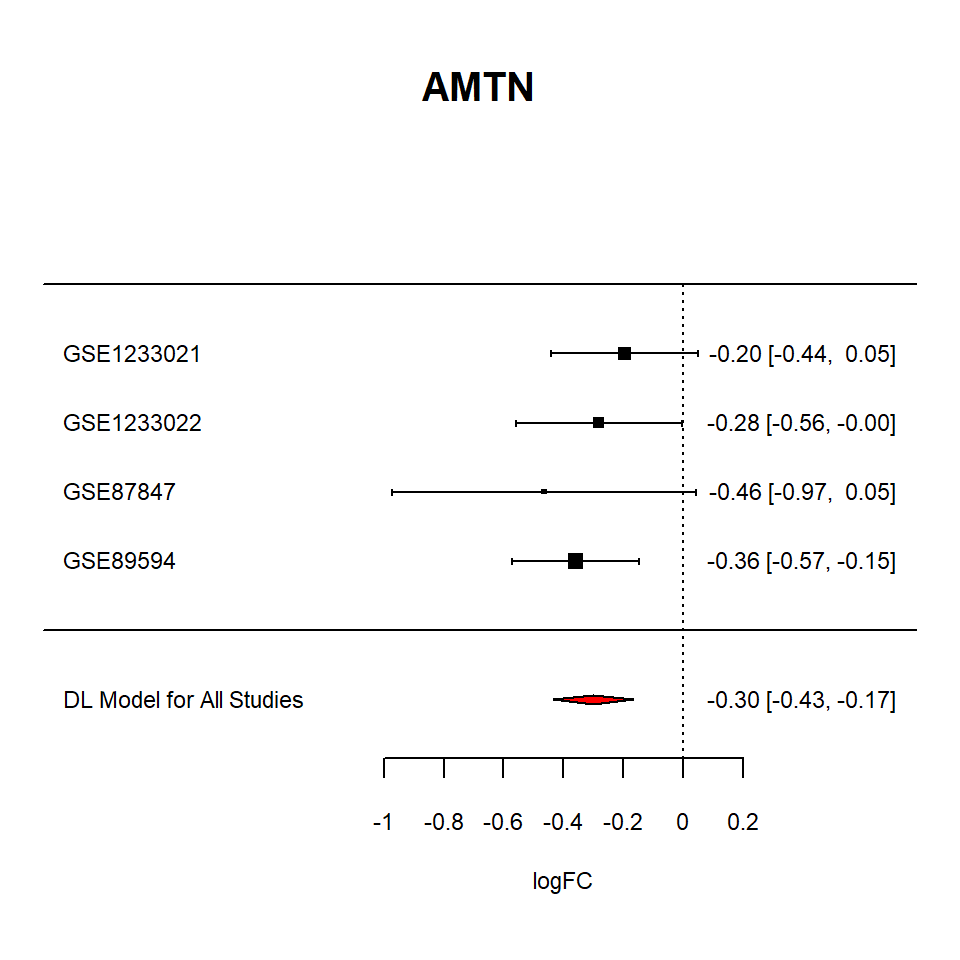

```r
knitr::include_graphics("plots/AMTN_FOREST.png")
```

**Funnel plot**

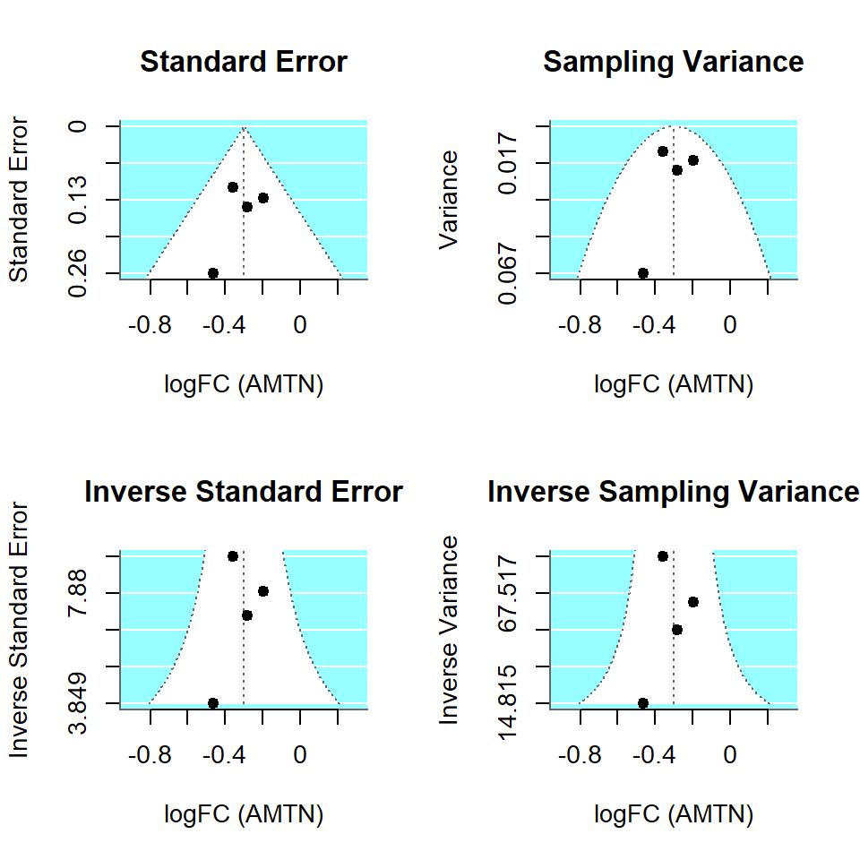

```r
knitr::include_graphics("plots/AMTN_FUNNEL.png")
```

**Incluence plot**

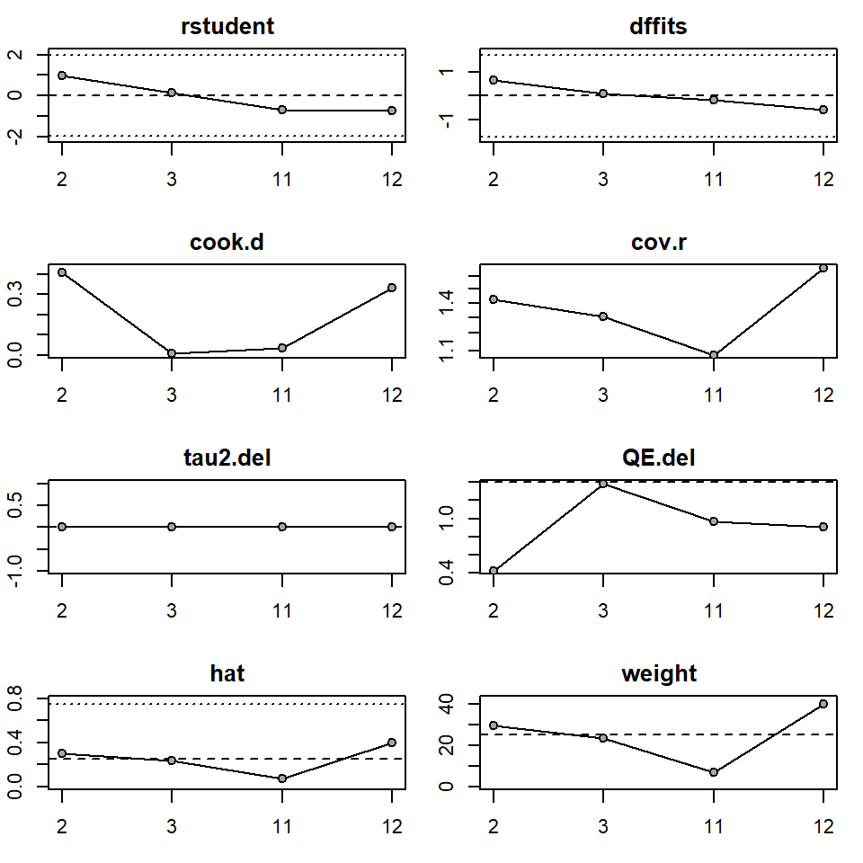

```r
knitr::include_graphics("plots/AMTN_INFLUENCE.png")
```

### FAM205B

**Statistics of FAM205B meta-analisys**

```r
kable(sig.genes.df['FAM205B',1:11])
```

|  | lower_bound | logFC | upper_bound | pvalue | QE | QEp | SE | tau2 | I2 | H2 | p.adjust.fdr |
| --- | --- | --- | --- | --- | --- | --- | --- | --- | --- | --- | --- |
| FAM205B | -0.173 | -0.118 | -0.064 | 0 | 0.076 | 0.783 | 0.028 | 0 | 0 | 1 | 0.026 |

[Gene information](https://www.genecards.org/cgi-bin/carddisp.pl?gene=FAM205B)

**Forest plot**

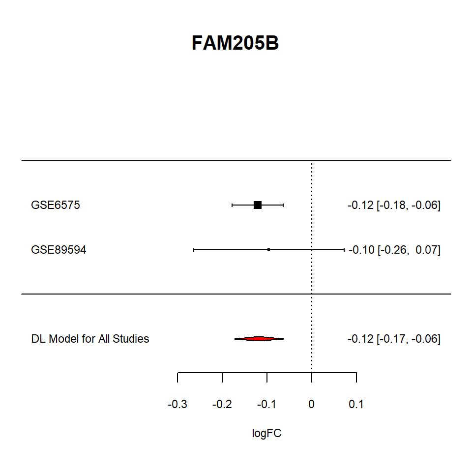

```r
knitr::include_graphics("plots/FAM205B_FOREST.png")
```

**Funnel plot**

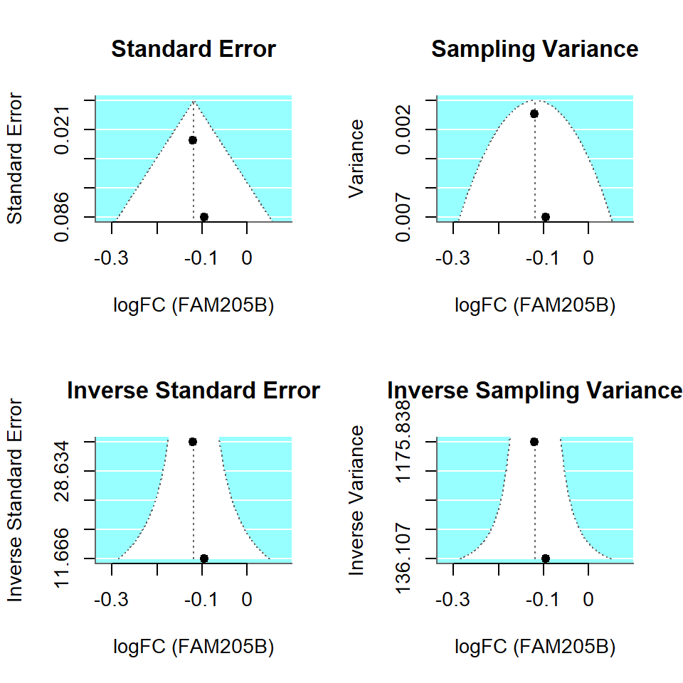

```r
knitr::include_graphics("plots/FAM205B_FUNNEL.png")
```

**Incluence plot**

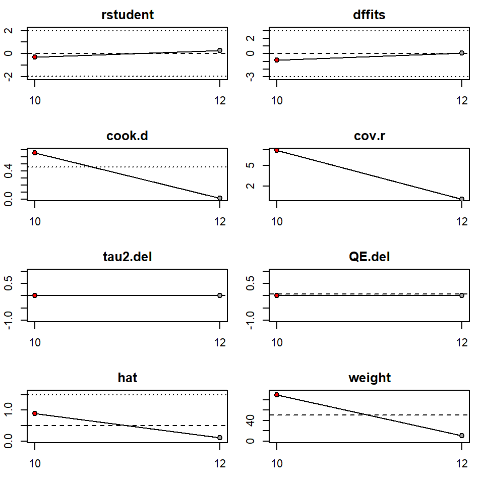

```r
knitr::include_graphics("plots/FAM205B_INFLUENCE.png")
```

### RYBP

**Statistics of RYBP meta-analisys**

```r
kable(sig.genes.df['RYBP',1:11])
```

|  | lower_bound | logFC | upper_bound | pvalue | QE | QEp | SE | tau2 | I2 | H2 | p.adjust.fdr |
| --- | --- | --- | --- | --- | --- | --- | --- | --- | --- | --- | --- |
| RYBP | 0.055 | 0.101 | 0.148 | 0 | 8.121 | 0.617 | 0.024 | 0 | 0 | 1 | 0.026 |

[Gene information](https://www.genecards.org/cgi-bin/carddisp.pl?gene=RYBP)

**Forest plot**

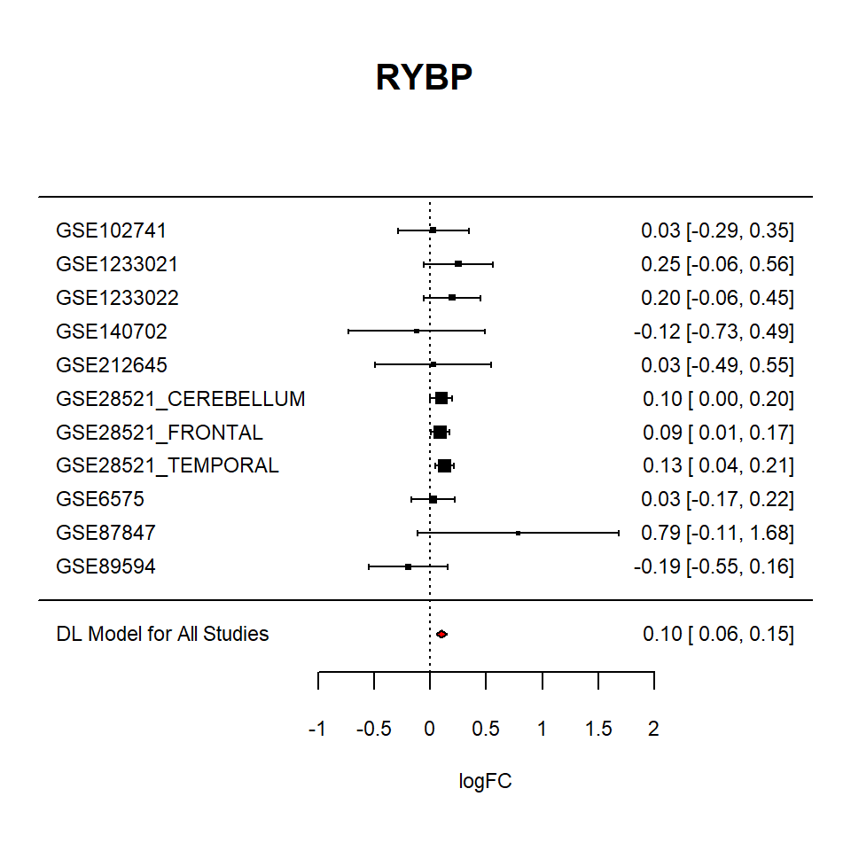

```r
knitr::include_graphics("plots/RYBP_FOREST.png")
```

**Funnel plot**

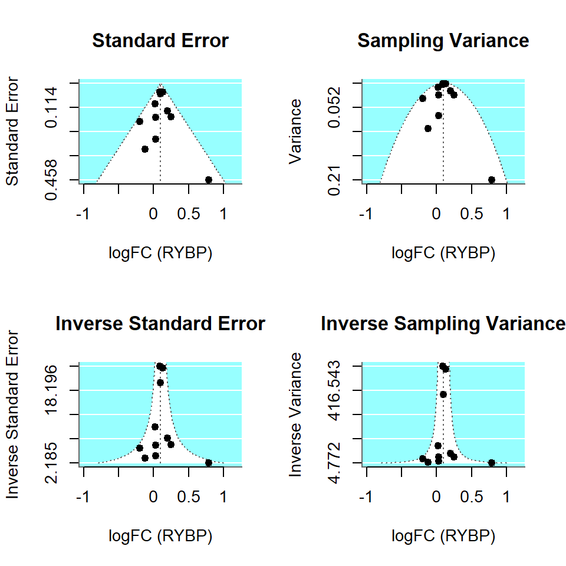

```r
knitr::include_graphics("plots/RYBP_FUNNEL.png")
```

**Incluence plot**

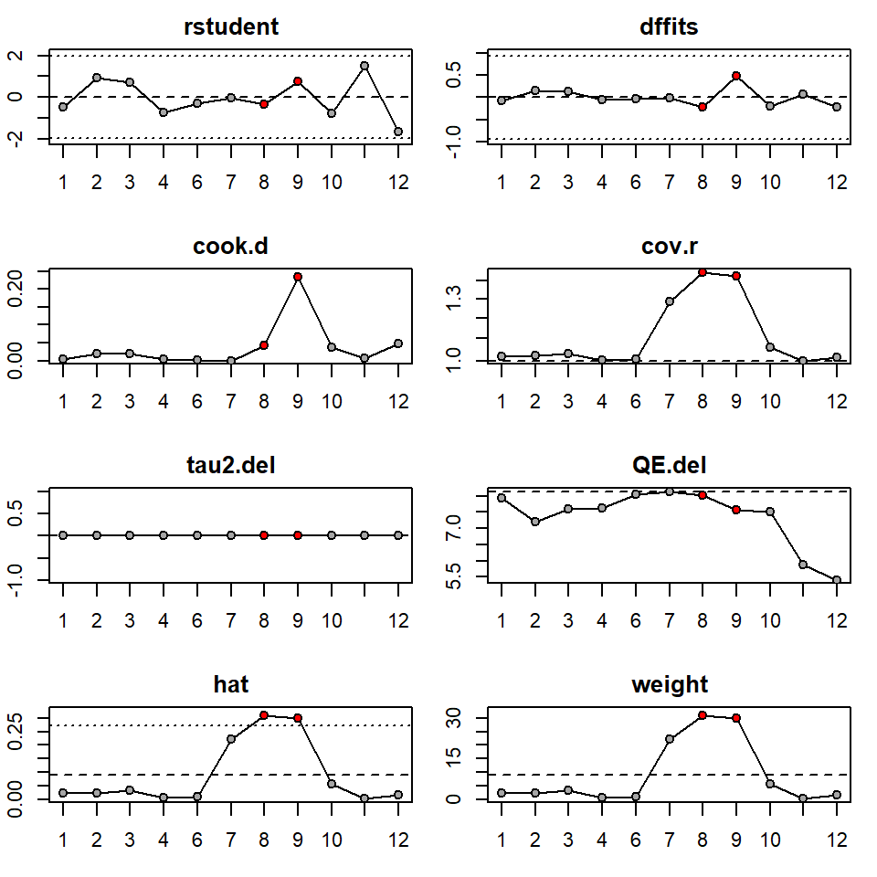

```r
knitr::include_graphics("plots/RYBP_INFLUENCE.png")
```

### BSCL2

**Statistics of BSCL2 meta-analisys**

```r
kable(sig.genes.df['BSCL2',1:11])
```

|  | lower_bound | logFC | upper_bound | pvalue | QE | QEp | SE | tau2 | I2 | H2 | p.adjust.fdr |
| --- | --- | --- | --- | --- | --- | --- | --- | --- | --- | --- | --- |
| BSCL2 | -0.064 | -0.044 | -0.023 | 0 | 2.847 | 0.944 | 0.01 | 0 | 0 | 1 | 0.029 |

[Gene information](https://www.genecards.org/cgi-bin/carddisp.pl?gene=BSCL2)

**Forest plot**

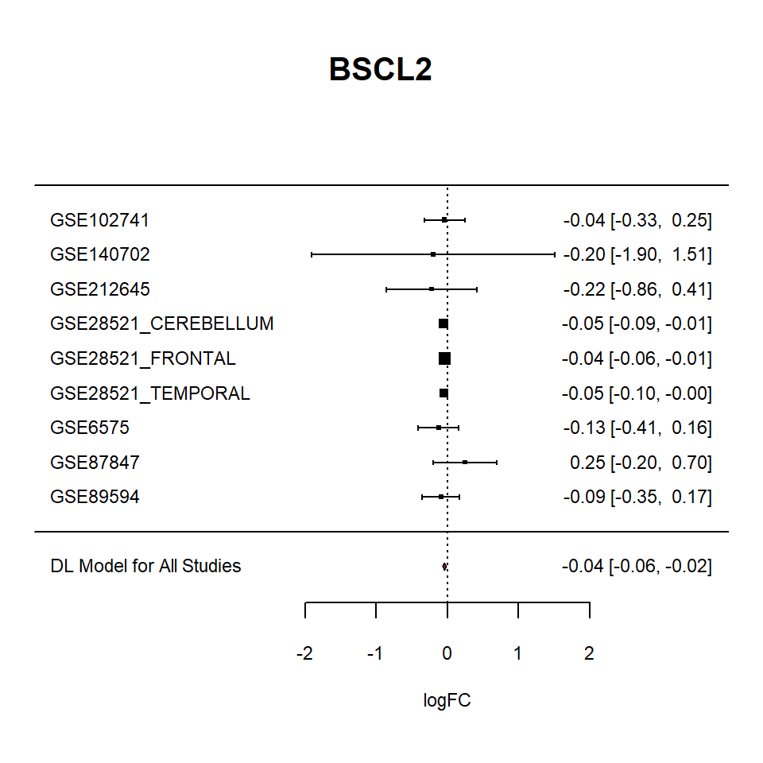

```r
knitr::include_graphics("plots/BSCL2_FOREST.png")
```

**Funnel plot**

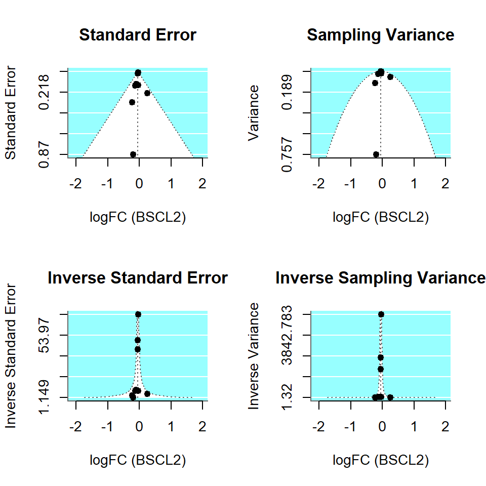

```r
knitr::include_graphics("plots/BSCL2_FUNNEL.png")
```

**Incluence plot**

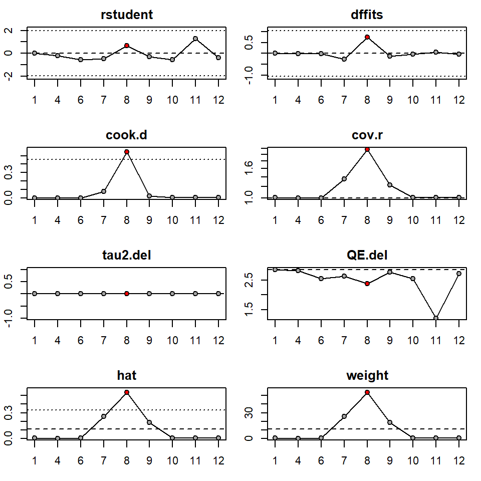

```r
knitr::include_graphics("plots/BSCL2_INFLUENCE.png")
```

### FCGBP

**Statistics of FCGBP meta-analisys**

```r
kable(sig.genes.df['FCGBP',1:11])
```

|  | lower_bound | logFC | upper_bound | pvalue | QE | QEp | SE | tau2 | I2 | H2 | p.adjust.fdr |
| --- | --- | --- | --- | --- | --- | --- | --- | --- | --- | --- | --- |
| FCGBP | 0.156 | 0.29 | 0.424 | 0 | 11.497 | 0.243 | 0.068 | 0.009 | 21.716 | 1.277 | 0.03 |

[Gene information](https://www.genecards.org/cgi-bin/carddisp.pl?gene=FCGBP)

**Forest plot**

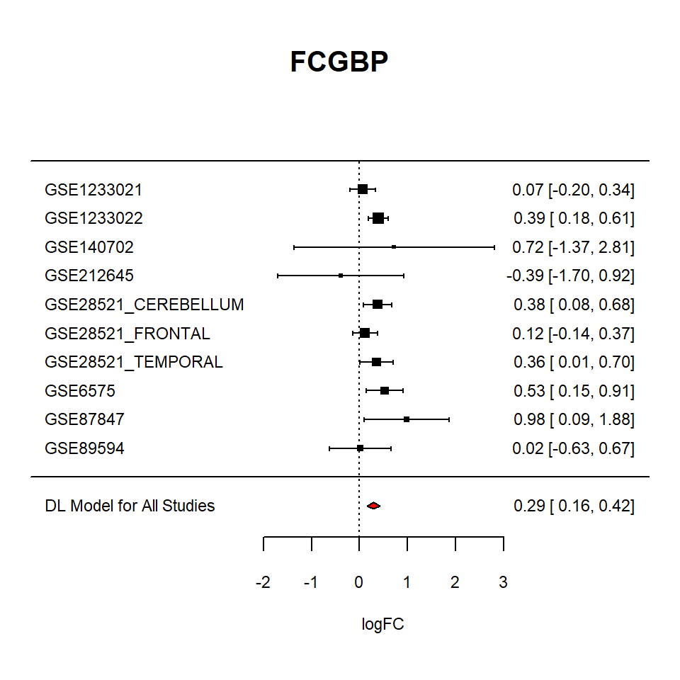

```r
knitr::include_graphics("plots/FCGBP_FOREST.png")
```

**Funnel plot**

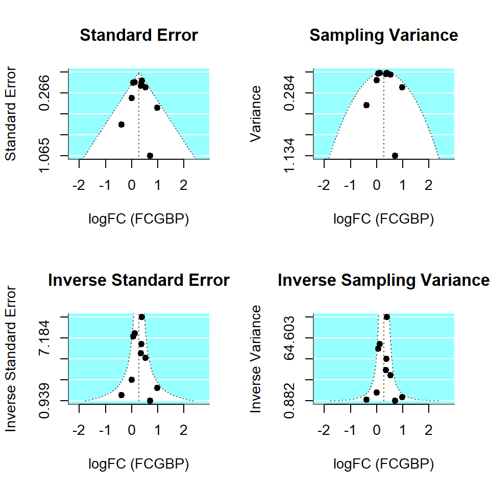

```r
knitr::include_graphics("plots/FCGBP_FUNNEL.png")
```

**Incluence plot**

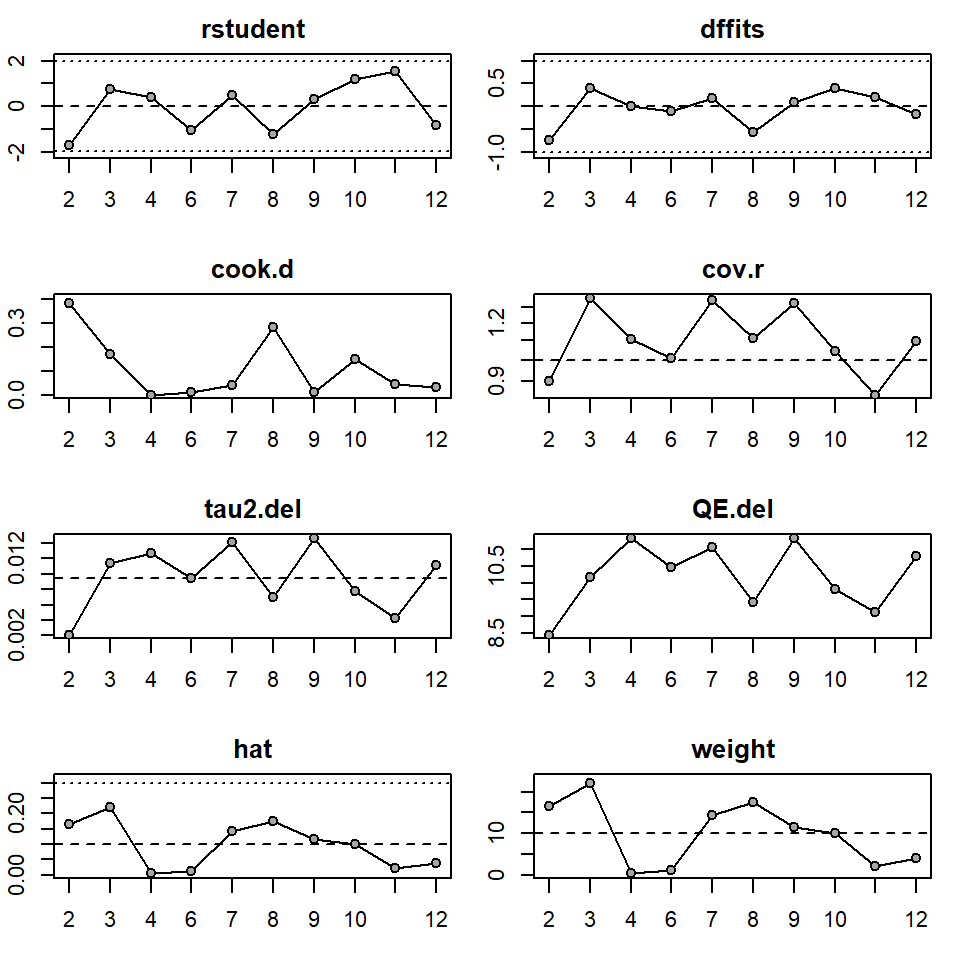

```r
knitr::include_graphics("plots/FCGBP_INFLUENCE.png")
```

### LRRCC1

**Statistics of LRRCC1 meta-analisys**

```r
kable(sig.genes.df['LRRCC1',1:11])
```

|  | lower_bound | logFC | upper_bound | pvalue | QE | QEp | SE | tau2 | I2 | H2 | p.adjust.fdr |
| --- | --- | --- | --- | --- | --- | --- | --- | --- | --- | --- | --- |
| LRRCC1 | 0.054 | 0.1 | 0.147 | 0 | 5.704 | 0.839 | 0.024 | 0 | 0 | 1 | 0.031 |

[Gene information](https://www.genecards.org/cgi-bin/carddisp.pl?gene=LRRCC1)

**Forest plot**

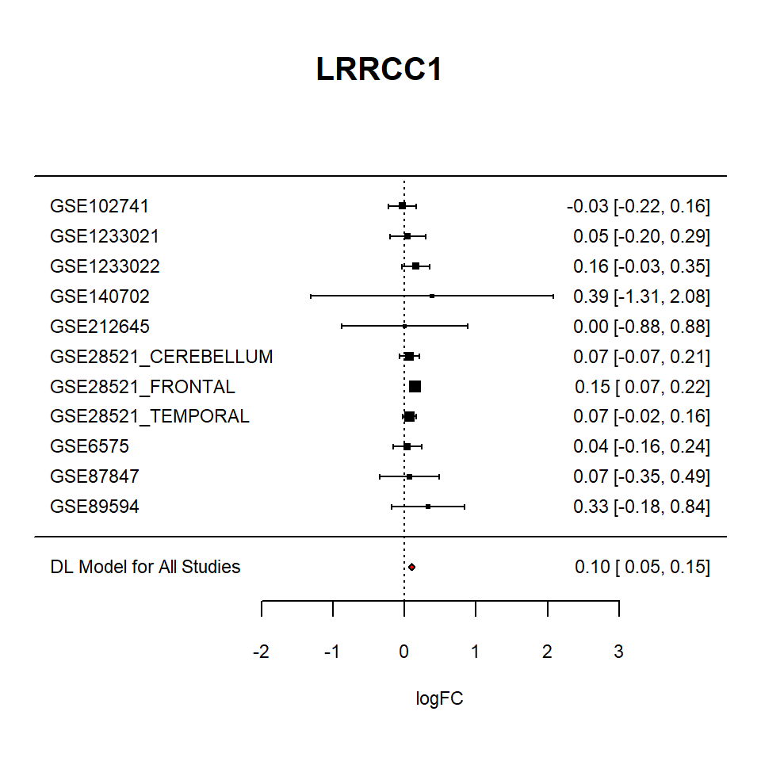

```r
knitr::include_graphics("plots/LRRCC1_FOREST.png")
```

**Funnel plot**

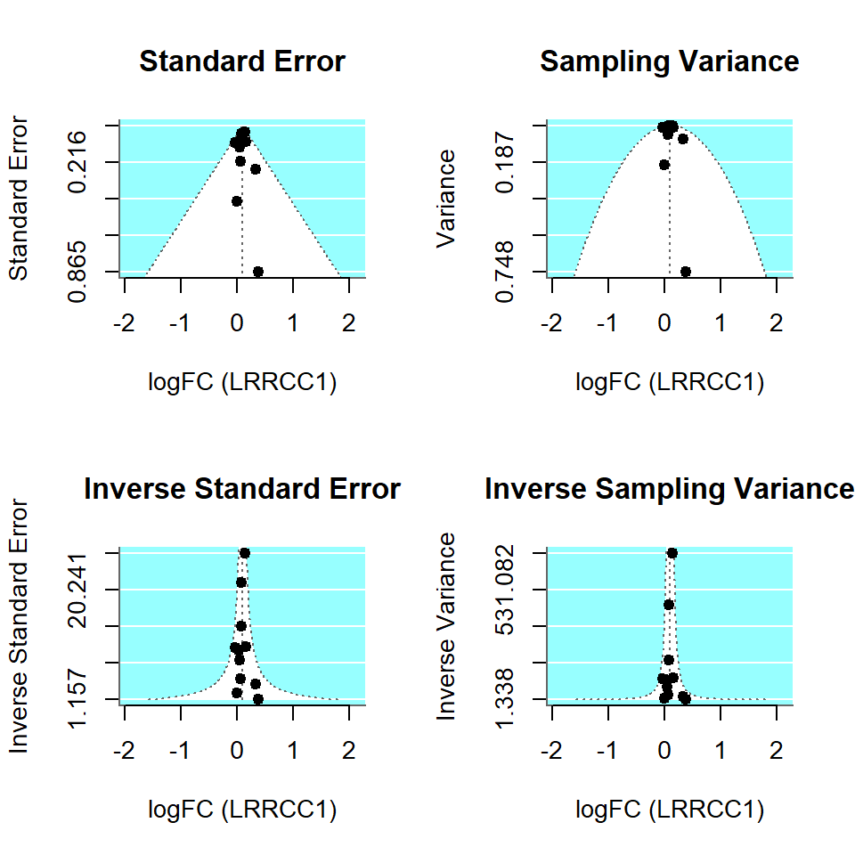

```r
knitr::include_graphics("plots/LRRCC1_FUNNEL.png")
```

**Incluence plot**

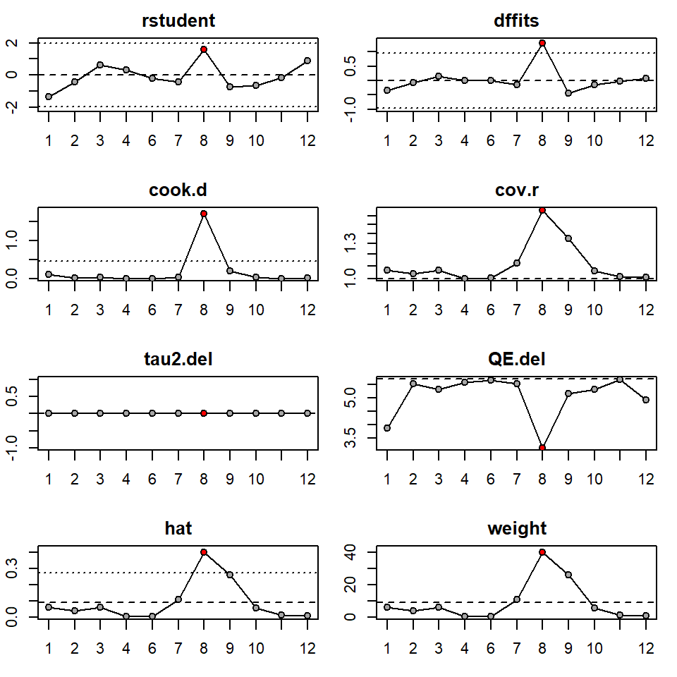

```r
knitr::include_graphics("plots/LRRCC1_INFLUENCE.png")
```

### MLEC

**Statistics of MLEC meta-analisys**

```r
kable(sig.genes.df['MLEC',1:11])
```

|  | lower_bound | logFC | upper_bound | pvalue | QE | QEp | SE | tau2 | I2 | H2 | p.adjust.fdr |
| --- | --- | --- | --- | --- | --- | --- | --- | --- | --- | --- | --- |
| MLEC | 0.134 | 0.253 | 0.372 | 0 | 1.782 | 0.939 | 0.061 | 0 | 0 | 1 | 0.033 |

[Gene information](https://www.genecards.org/cgi-bin/carddisp.pl?gene=MLEC)

**Forest plot**

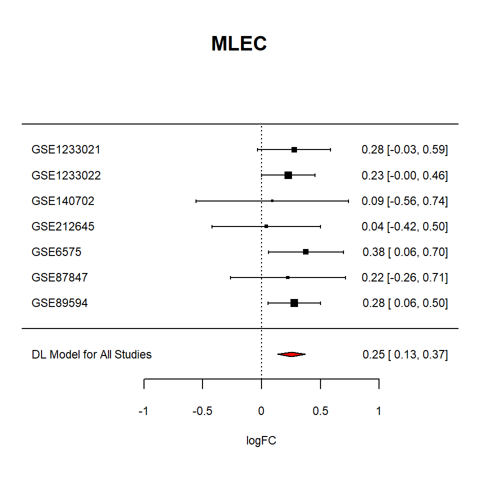

```r
knitr::include_graphics("plots/MLEC_FOREST.png")
```

**Funnel plot**

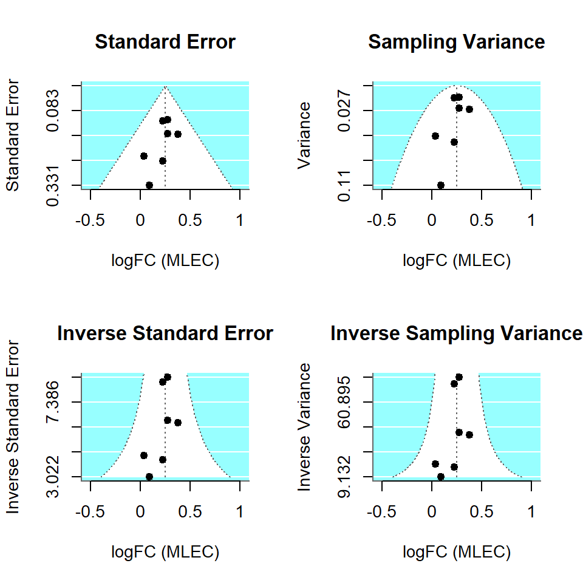

```r
knitr::include_graphics("plots/MLEC_FUNNEL.png")
```

**Incluence plot**

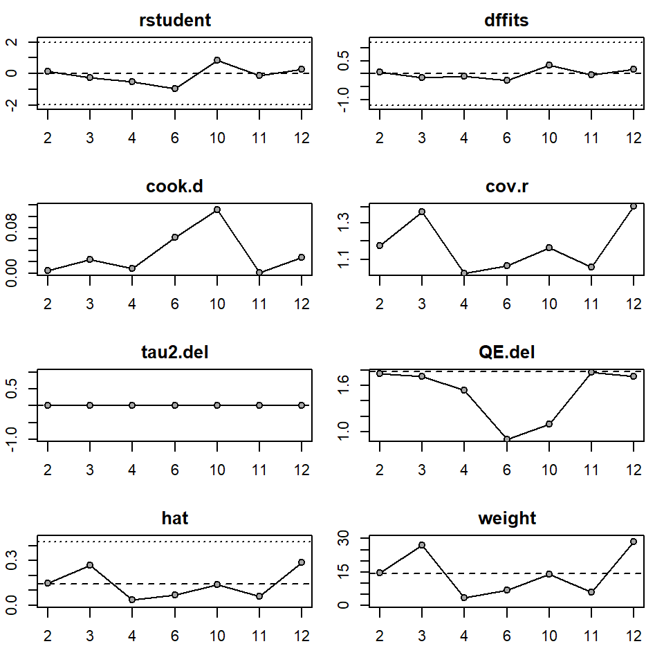

```r
knitr::include_graphics("plots/MLEC_INFLUENCE.png")
```

### PIB5PA

**Statistics of PIB5PA meta-analisys**

```r
kable(sig.genes.df['PIB5PA',1:11])
```

|  | lower_bound | logFC | upper_bound | pvalue | QE | QEp | SE | tau2 | I2 | H2 | p.adjust.fdr |
| --- | --- | --- | --- | --- | --- | --- | --- | --- | --- | --- | --- |
| PIB5PA | -0.147 | -0.1 | -0.053 | 0 | 2.354 | 0.502 | 0.024 | 0 | 0 | 1 | 0.033 |

[Gene information](https://www.genecards.org/cgi-bin/carddisp.pl?gene=PIB5PA)

**Forest plot**

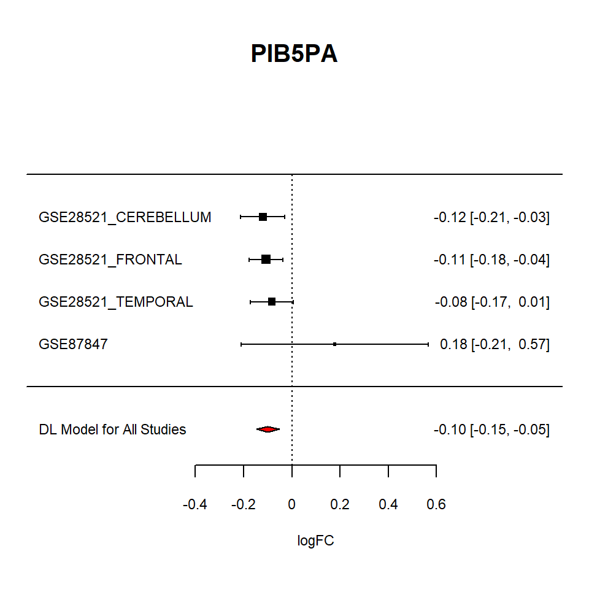

```r
knitr::include_graphics("plots/PIB5PA_FOREST.png")
```

**Funnel plot**

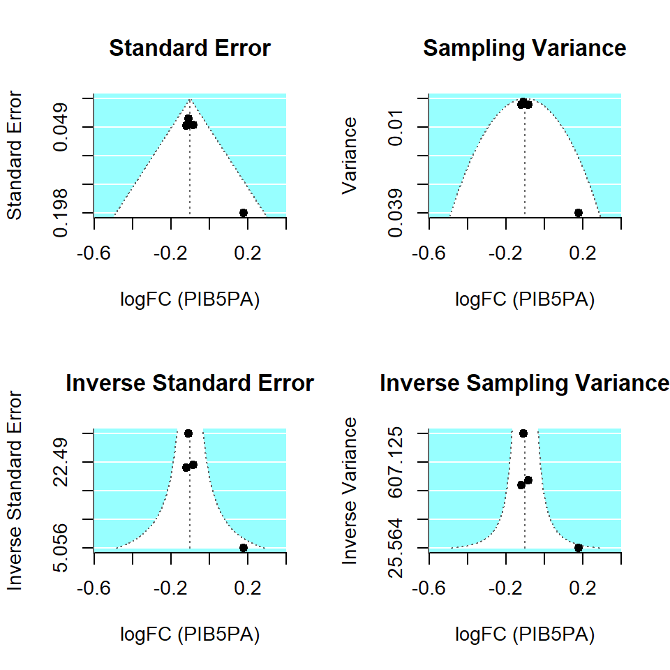

```r
knitr::include_graphics("plots/PIB5PA_FUNNEL.png")
```

**Incluence plot**

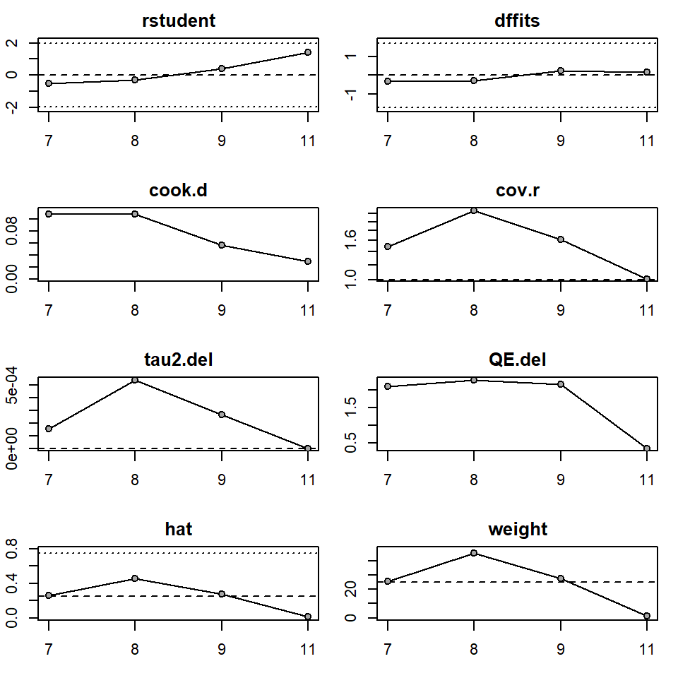

```r
knitr::include_graphics("plots/PIB5PA_INFLUENCE.png")
```

### ISOC2

**Statistics of ISOC2 meta-analisys**

```r
kable(sig.genes.df['ISOC2',1:11])
```

|  | lower_bound | logFC | upper_bound | pvalue | QE | QEp | SE | tau2 | I2 | H2 | p.adjust.fdr |
| --- | --- | --- | --- | --- | --- | --- | --- | --- | --- | --- | --- |
| ISOC2 | 0.037 | 0.07 | 0.104 | 0 | 6.712 | 0.568 | 0.017 | 0 | 0 | 1 | 0.035 |

[Gene information](https://www.genecards.org/cgi-bin/carddisp.pl?gene=ISOC2)

**Forest plot**

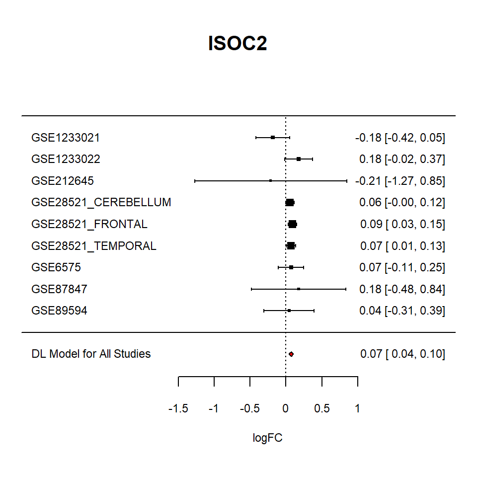

```r
knitr::include_graphics("plots/ISOC2_FOREST.png")
```

**Funnel plot**

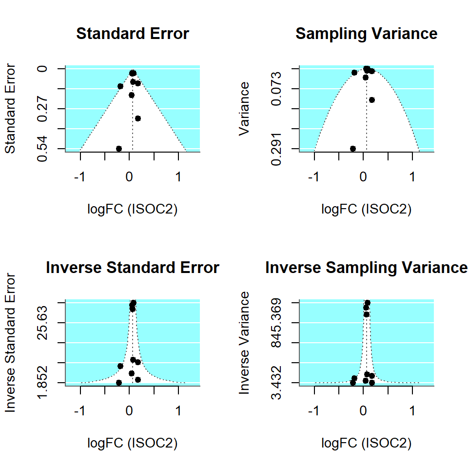

```r
knitr::include_graphics("plots/ISOC2_FUNNEL.png")
```

**Incluence plot**

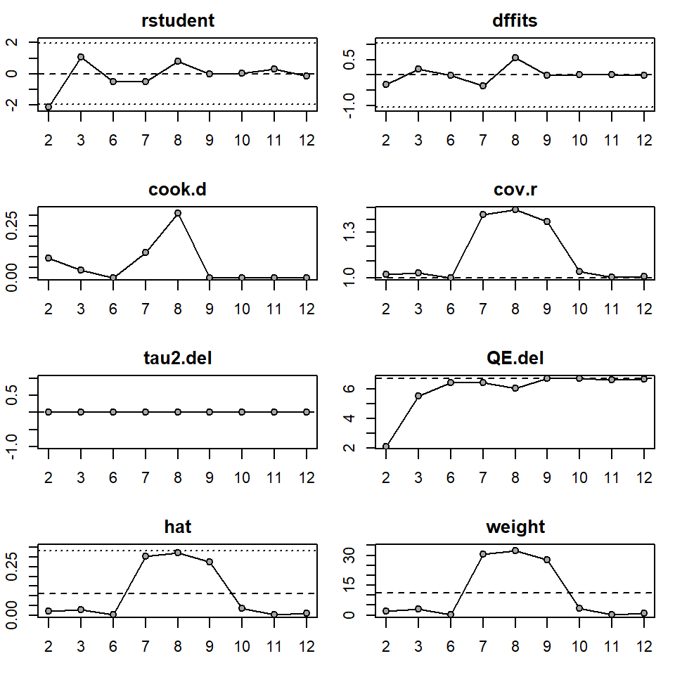

```r
knitr::include_graphics("plots/ISOC2_INFLUENCE.png")
```

### SMARCA5

**Statistics of SMARCA5 meta-analisys**

```r
kable(sig.genes.df['SMARCA5',1:11])
```

|  | lower_bound | logFC | upper_bound | pvalue | QE | QEp | SE | tau2 | I2 | H2 | p.adjust.fdr |
| --- | --- | --- | --- | --- | --- | --- | --- | --- | --- | --- | --- |
| SMARCA5 | 0.036 | 0.069 | 0.101 | 0 | 6.47 | 0.595 | 0.017 | 0 | 0 | 1 | 0.036 |

[Gene information](https://www.genecards.org/cgi-bin/carddisp.pl?gene=SMARCA5)

**Forest plot**

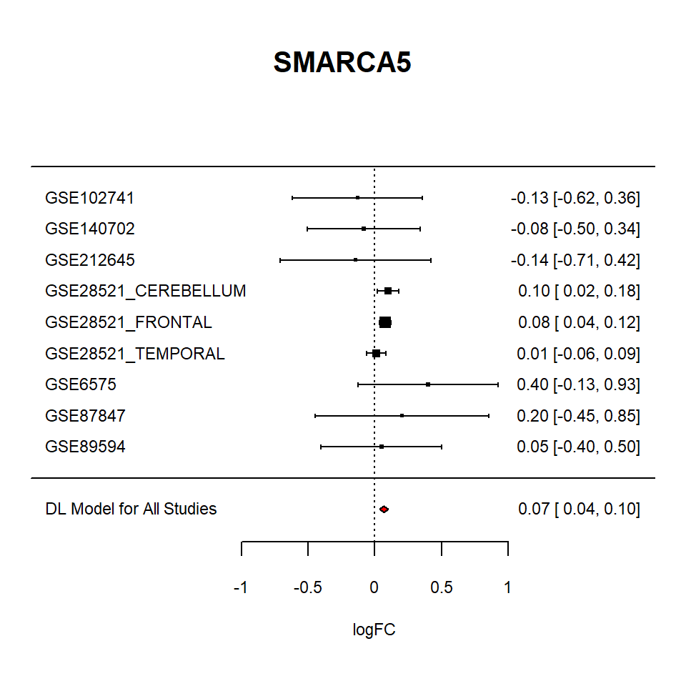

```r
knitr::include_graphics("plots/SMARCA5_FOREST.png")
```

**Funnel plot**

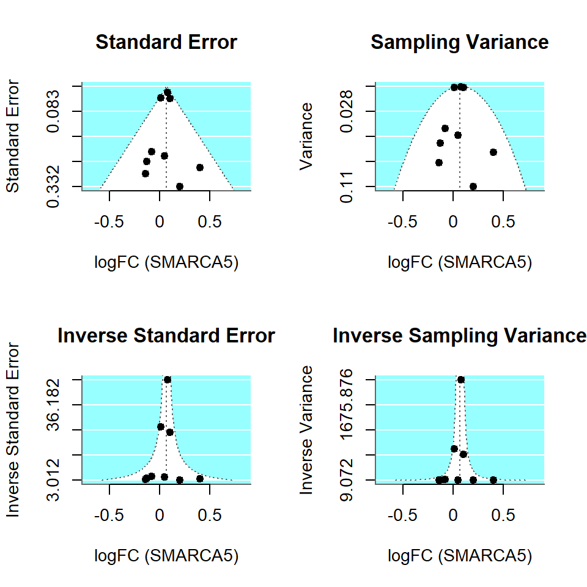

```r
knitr::include_graphics("plots/SMARCA5_FUNNEL.png")
```

**Incluence plot**

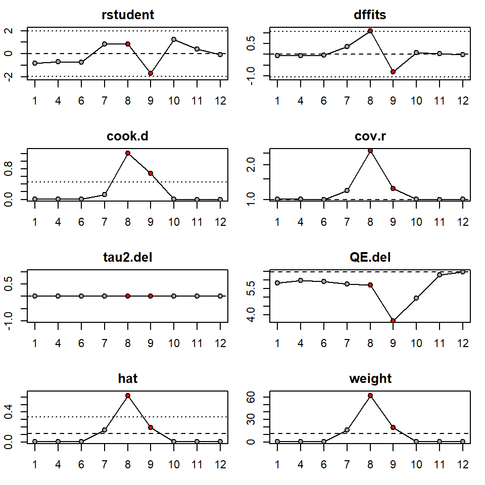

```r
knitr::include_graphics("plots/SMARCA5_INFLUENCE.png")
```

### TMCC1

**Statistics of TMCC1 meta-analisys**

```r
kable(sig.genes.df['TMCC1',1:11])
```

|  | lower_bound | logFC | upper_bound | pvalue | QE | QEp | SE | tau2 | I2 | H2 | p.adjust.fdr |
| --- | --- | --- | --- | --- | --- | --- | --- | --- | --- | --- | --- |
| TMCC1 | -0.135 | -0.091 | -0.048 | 0 | 11.711 | 0.305 | 0.022 | 0.001 | 14.61 | 1.171 | 0.036 |

[Gene information](https://www.genecards.org/cgi-bin/carddisp.pl?gene=TMCC1)

**Forest plot**

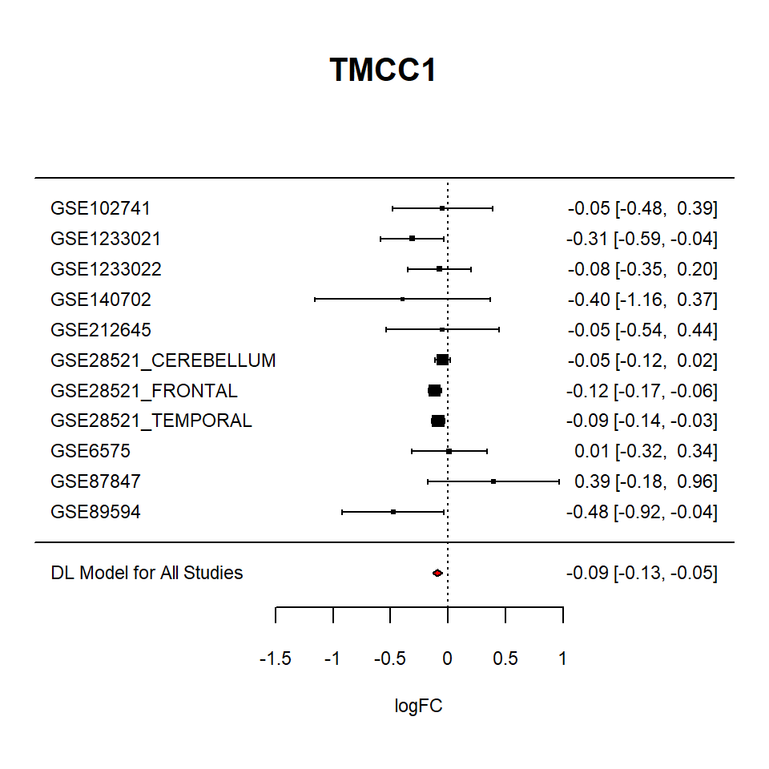

```r
knitr::include_graphics("plots/TMCC1_FOREST.png")
```

**Funnel plot**

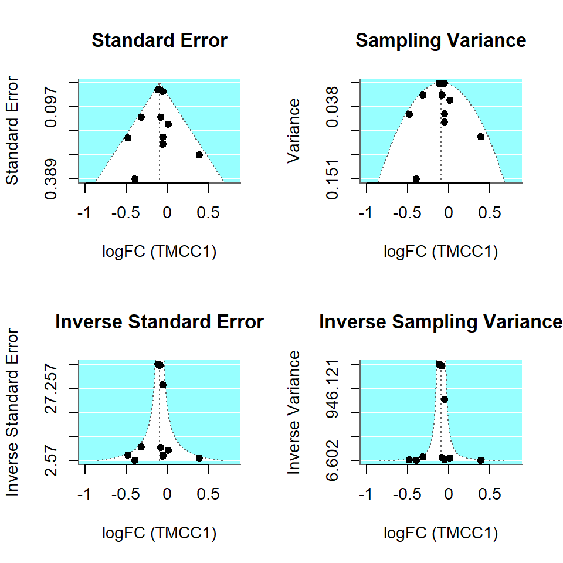

```r
knitr::include_graphics("plots/TMCC1_FUNNEL.png")
```

**Incluence plot**

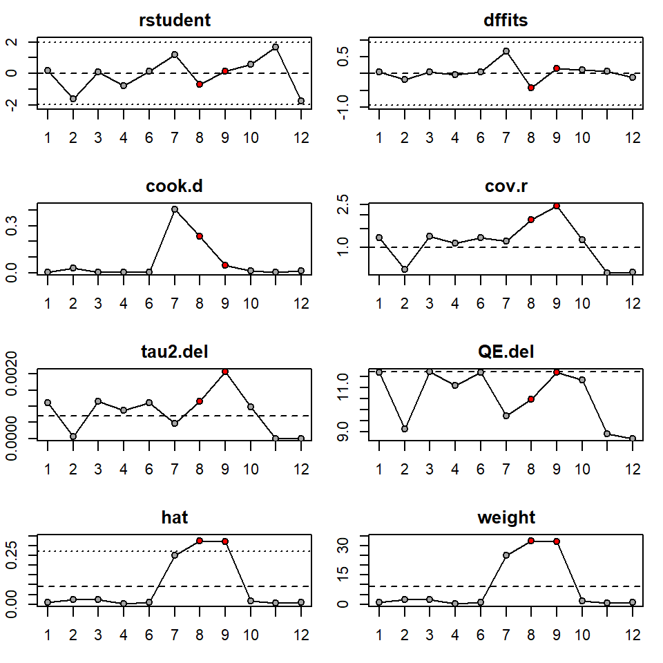

```r
knitr::include_graphics("plots/TMCC1_INFLUENCE.png")
```

### USP46

**Statistics of USP46 meta-analisys**

```r
kable(sig.genes.df['USP46',1:11])
```

|  | lower_bound | logFC | upper_bound | pvalue | QE | QEp | SE | tau2 | I2 | H2 | p.adjust.fdr |
| --- | --- | --- | --- | --- | --- | --- | --- | --- | --- | --- | --- |
| USP46 | 0.032 | 0.06 | 0.089 | 0 | 4.404 | 0.883 | 0.015 | 0 | 0 | 1 | 0.038 |

[Gene information](https://www.genecards.org/cgi-bin/carddisp.pl?gene=USP46)

**Forest plot**

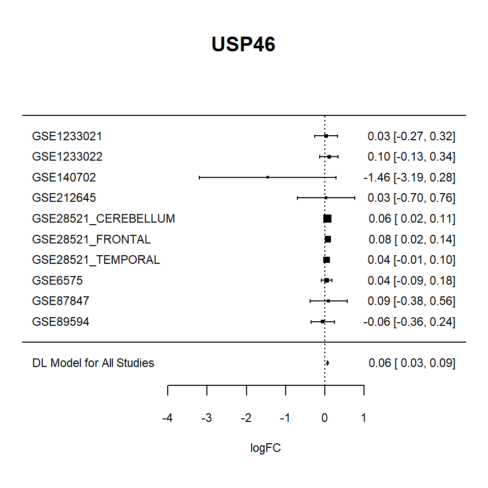

```r
knitr::include_graphics("plots/USP46_FOREST.png")
```

**Funnel plot**

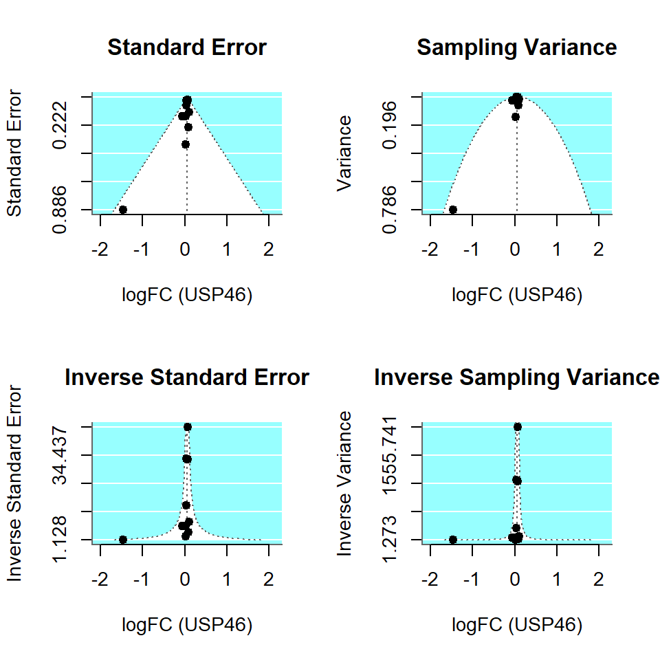

```r
knitr::include_graphics("plots/USP46_FUNNEL.png")
```

**Incluence plot**

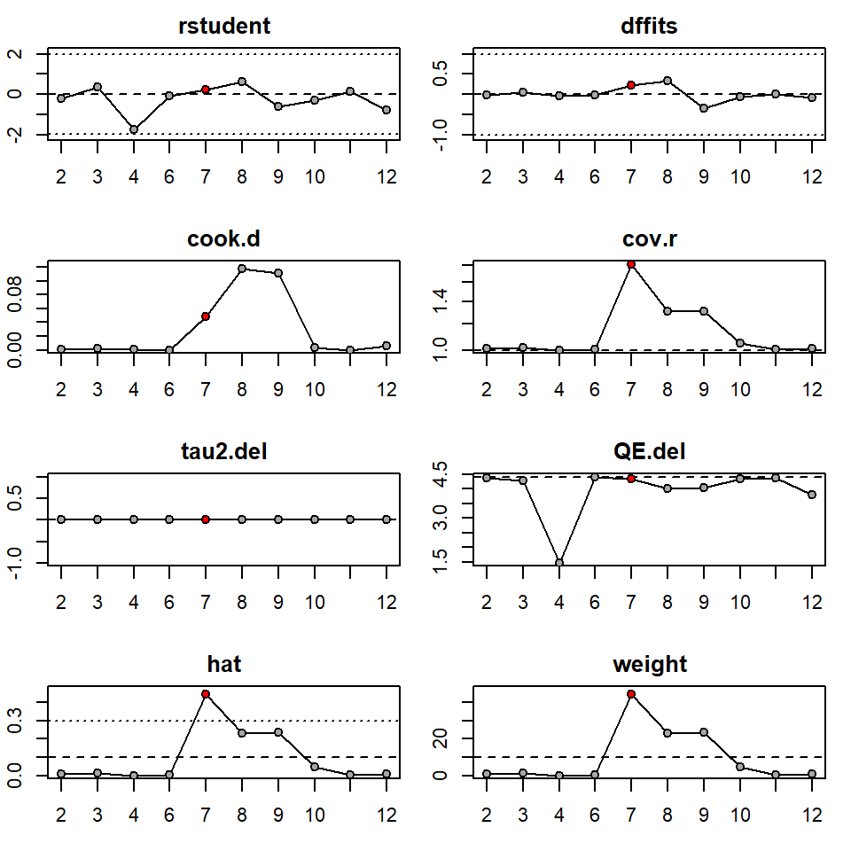

```r
knitr::include_graphics("plots/USP46_INFLUENCE.png")
```

### sessionInfo

```r
date()
```

```
## [1] "Wed Apr 17 20:02:43 2024"
```